# Dranchuk-Purvis-Robinson correlation

2019-07-31

## Get `z` at selected `Ppr` and `Tpr`

Use the corelation to calculate `z`. From the Standing-Katz chart we obtain `z` at a digitized point at the given `Tpr` and `Ppr`.

```r
# get a z value
library(zFactor)

ppr <- 1.5
tpr <- 2.0

z.calc <- z.DranchukPurvisRobinson(pres.pr = ppr, temp.pr = tpr)

# get a z value from the SK chart at the same Ppr and Tpr
z.chart <- getStandingKatzMatrix(tpr_vector = tpr,
                      pprRange = "lp")[1, as.character(ppr)]

# calculate the APE
ape <- abs((z.calc - z.chart) / z.chart) * 100

df <- as.data.frame(list(Ppr = ppr,  z.calc =z.calc, z.chart = z.chart, ape=ape))
rownames(df) <- tpr
df
# HY = 0.9580002; # DAK = 0.9551087
```

```
  Ppr    z.calc z.chart       ape
2 1.5 0.9546382   0.956 0.1424501
```

## Get `z` at selected `Ppr` and `Tpr=1.1`

From the Standing-Katz chart we obtain `z` at a digitized point:

```r
library(zFactor)

ppr <- 1.5
tpr <- 1.1
z.calc <- z.DranchukPurvisRobinson(pres.pr = ppr, temp.pr = tpr)

# From the Standing-Katz chart we obtain a digitized point:
z.chart <- getStandingKatzMatrix(tpr_vector = tpr,
                      pprRange = "lp")[1, as.character(ppr)]

# calculate the APE
ape <- abs((z.calc - z.chart) / z.chart) * 100

df <- as.data.frame(list(Ppr = ppr,  z.calc =z.calc, z.chart = z.chart, ape=ape))
rownames(df) <- tpr
df
```

```
    Ppr    z.calc z.chart      ape
1.1 1.5 0.4429389   0.426 3.976272
```

> At lower `Tpr` we can see that there is some difference between the values of z from the DPR calculation and the value read from the Standing-Katz chart.

## Get values of `z` for combinations of `Ppr` and `Tpr`

In this example we provide vectors instead of a single point. With the same `ppr` and `tpr` vectors that we use for the correlation, we do the same for the `Standing-Katz` chart. We want to compare both and find the `absolute percentage error`.

```r
# test HY with 1st-derivative using the values from paper
ppr <- c(0.5, 1.5, 2.5, 3.5, 4.5, 5.5, 6.5)
tpr <- c(1.05, 1.1, 1.7, 2)

# calculate using the correlation
z.calc <- z.DranchukPurvisRobinson(ppr, tpr)

# With the same ppr and tpr vector, we do the same for the Standing-Katz chart
z.chart <- getStandingKatzMatrix(ppr_vector = ppr, tpr_vector = tpr)
ape <- abs((z.calc - z.chart) / z.chart) * 100

# calculate the APE
cat("z.correlation \n"); print(z.calc)
cat("\n z.chart \n"); print(z.chart)
cat("\n APE \n"); print(ape)
```

```
z.correlation
           0.5       1.5       2.5       3.5       4.5       5.5       6.5
1.05 0.8299757 0.2849670 0.3874732 0.5071451 0.6251306 0.7407256 0.8540945
1.1  0.8566368 0.4429389 0.4120547 0.5173680 0.6278497 0.7376397 0.8458855
1.7  0.9677844 0.9121791 0.8752677 0.8630002 0.8743271 0.9033216 0.9440582
2    0.9822021 0.9546382 0.9399310 0.9391490 0.9512966 0.9740256 1.0047347

 z.chart
       0.5   1.5   2.5   3.5   4.5   5.5   6.5
1.05 0.829 0.253 0.343 0.471 0.598 0.727 0.846
1.10 0.854 0.426 0.393 0.500 0.615 0.729 0.841
1.70 0.968 0.914 0.876 0.857 0.864 0.897 0.942
2.00 0.982 0.956 0.941 0.937 0.945 0.969 1.003

 APE
            0.5        1.5         2.5       3.5       4.5       5.5
1.05 0.11769033 12.6351920 12.96594664 7.6741203 4.5368917 1.8879838
1.1  0.30875526  3.9762721  4.84851814 3.4735929 2.0893900 1.1851375
1.7  0.02227128  0.1992260  0.08360117 0.7001396 1.1952693 0.7047482
2    0.02057809  0.1424501  0.11359921 0.2293483 0.6663029 0.5186423
           6.5
1.05 0.9567950
1.1  0.5809181
1.7  0.2184874
2    0.1729508
```

> You can see errors of 12.64% and 12.97% in the isotherm `Tpr=1.05`. Other errors, greater than one, can also be found at the isotherm `Tpr=1.1`: 4.85%. Then, the rest of the `Tpr` curves are fine.

## Analyze the error at the `isotherms`

Applying the function `summary` over the transpose of the matrix:

```r
sum_t_ape <- summary(t(ape))
sum_t_ape
```

```
      1.05              1.1              1.7                2
 Min.   : 0.1177   Min.   :0.3088   Min.   :0.02227   Min.   :0.02058
 1st Qu.: 1.4224   1st Qu.:0.8830   1st Qu.:0.14141   1st Qu.:0.12802
 Median : 4.5369   Median :2.0894   Median :0.21849   Median :0.17295
 Mean   : 5.8249   Mean   :2.3518   Mean   :0.44625   Mean   :0.26627
 3rd Qu.:10.1547   3rd Qu.:3.7249   3rd Qu.:0.70244   3rd Qu.:0.37400
 Max.   :12.9659   Max.   :4.8485   Max.   :1.19527   Max.   :0.66630
```

> We see that the errors at `Tpr=1.05` in `z` are considerable with a Min. : 0.1177 % and Max. :12.9659 %, and a Min. :0.3088 % and Max. :4.8485 % for `Tpr=1.10`. We will explore later a comparative **tile** chart where we confirm these early calculations.

## Analyze the error for greater values of `Tpr`

```r
library(zFactor)
# enter vectors for Tpr and Ppr
tpr2 <- c(1.2, 1.3, 1.5, 2.0, 3.0)
ppr2 <- c(0.5, 1.5, 2.5, 3.5, 4.5, 5.5)
# get z values from the SK chart
z.chart <- getStandingKatzMatrix(ppr_vector = ppr2, tpr_vector = tpr2, pprRange = "lp")

# We do the same with the DPR correlation:
# calculate z values at lower values of Tpr
z.calc <- z.DranchukPurvisRobinson(pres.pr = ppr2, temp.pr = tpr2)
ape <- abs((z.calc - z.chart) / z.chart) * 100

# calculate the APE
cat("z.correlation \n"); print(z.calc)
cat("\n z.chart \n"); print(z.chart)
cat("\n APE \n"); print(ape)
```

```
z.correlation
          0.5       1.5       2.5       3.5       4.5       5.5
1.2 0.8944622 0.6506542 0.5167723 0.5620069 0.6486093 0.7435619
1.3 0.9197157 0.7525940 0.6366665 0.6337883 0.6891997 0.7650171
1.5 0.9504834 0.8583491 0.7926325 0.7720713 0.7914322 0.8348883
2   0.9822021 0.9546382 0.9399310 0.9391490 0.9512966 0.9740256
3   0.9982332 0.9990423 1.0054940 1.0171291 1.0332788 1.0531986

 z.chart
       0.5   1.5   2.5   3.5   4.5   5.5
1.20 0.893 0.657 0.519 0.565 0.650 0.741
1.30 0.916 0.756 0.638 0.633 0.684 0.759
1.50 0.948 0.859 0.794 0.770 0.790 0.836
2.00 0.982 0.956 0.941 0.937 0.945 0.969
3.00 1.002 1.009 1.018 1.029 1.041 1.056

 APE
           0.5        1.5       2.5       3.5       4.5       5.5
1.2 0.16373952 0.96587736 0.4292331 0.5297522 0.2139491 0.3457414
1.3 0.40564053 0.45053093 0.2090095 0.1245350 0.7601879 0.7927605
1.5 0.26196479 0.07577742 0.1722264 0.2689942 0.1812966 0.1329789
2   0.02057809 0.14245011 0.1135992 0.2293483 0.6663029 0.5186423
3   0.37592424 0.98689063 1.2284915 1.1536378 0.7417116 0.2652884
```

## Analyze the error at the `isotherms`

Applying the function `summary` over the transpose of the matrix to observe the error of the correlation at each isotherm.

```r
sum_t_ape <- summary(t(ape))
sum_t_ape
 # Hall-Yarborough
 #      1.2               1.3              1.5               2
 # Min.   :0.05224   Min.   :0.1105   Min.   :0.1021   Min.   :0.0809
 # 1st Qu.:0.09039   1st Qu.:0.2080   1st Qu.:0.1623   1st Qu.:0.1814
 # Median :0.28057   Median :0.3181   Median :0.1892   Median :0.1975
 # Mean   :0.30122   Mean   :0.3899   Mean   :0.2597   Mean   :0.2284
 # 3rd Qu.:0.51710   3rd Qu.:0.5355   3rd Qu.:0.3533   3rd Qu.:0.2627
 # Max.   :0.57098   Max.   :0.8131   Max.   :0.5162   Max.   :0.4338
 #       3
 # Min.   :0.09128
 # 1st Qu.:0.17466
 # Median :0.35252
 # Mean   :0.34820
 # 3rd Qu.:0.52184
 # Max.   :0.59923
```

```
      1.2              1.3              1.5                2
 Min.   :0.1637   Min.   :0.1245   Min.   :0.07578   Min.   :0.02058
 1st Qu.:0.2469   1st Qu.:0.2582   1st Qu.:0.14279   1st Qu.:0.12081
 Median :0.3875   Median :0.4281   Median :0.17676   Median :0.18590
 Mean   :0.4414   Mean   :0.4571   Mean   :0.18221   Mean   :0.28182
 3rd Qu.:0.5046   3rd Qu.:0.6828   3rd Qu.:0.24180   3rd Qu.:0.44632
 Max.   :0.9659   Max.   :0.7928   Max.   :0.26899   Max.   :0.66630
       3
 Min.   :0.2653
 1st Qu.:0.4674
 Median :0.8643
 Mean   :0.7920
 3rd Qu.:1.1120
 Max.   :1.2285
```

## Prepare to plot `SK` vs `DPR` correlation

The error bars represent the difference between the calculated values by the `DPR` corrrelation and the `z` values read from the Standing-Katz chart.

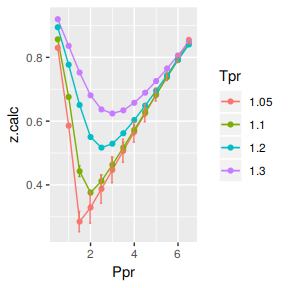

```
# A tibble: 52 x 5
   Tpr     Ppr z.chart z.calc       dif
   <chr> <dbl>   <dbl>  <dbl>     <dbl>
 1 1.05    0.5   0.829  0.830 -0.000976
 2 1.1     0.5   0.854  0.857 -0.00264
 3 1.2     0.5   0.893  0.894 -0.00146
 4 1.3     0.5   0.916  0.920 -0.00372
 5 1.05    1     0.589  0.586  0.00333
 6 1.1     1     0.669  0.676 -0.00689
 7 1.2     1     0.779  0.777  0.00205
 8 1.3     1     0.835  0.836 -0.000989
 9 1.05    1.5   0.253  0.285 -0.0320
10 1.1     1.5   0.426  0.443 -0.0169
# … with 42 more rows
```

```r
library(zFactor)
library(tibble)
library(ggplot2)

tpr2 <- c(1.05, 1.1, 1.2, 1.3)
ppr2 <- c(0.5, 1.0, 1.5, 2, 2.5, 3.0, 3.5, 4.0, 4.5, 5.0, 5.5, 6.0, 6.5)

sk_corr_2 <- createTidyFromMatrix(ppr2, tpr2, correlation = "DPR")
as.tibble(sk_corr_2)

p <- ggplot(sk_corr_2, aes(x=Ppr, y=z.calc, group=Tpr, color=Tpr)) +
    geom_line() +
    geom_point() +
    geom_errorbar(aes(ymin=z.calc-dif, ymax=z.calc+dif), width=.4,
                  position=position_dodge(0.05))
print(p)
```

We observe that with `Dranchuk-Purvis-Robinson` there are still errors or differences between the `z` values in the Standing-Katz chart and the values obtained from the correlation but they are not so bad as in the HY correlation.

## Analysis at the lowest `Tpr`

This is the isotherm where we see the greatest error.

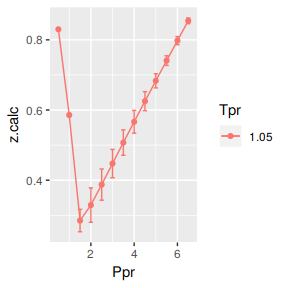

```
    Tpr Ppr z.chart    z.calc           dif
1  1.05 0.5   0.829 0.8299757 -0.0009756528
5  1.05 1.0   0.589 0.5856680  0.0033320375
9  1.05 1.5   0.253 0.2849670 -0.0319670358
13 1.05 2.0   0.280 0.3290685 -0.0490685223
17 1.05 2.5   0.343 0.3874732 -0.0444731970
21 1.05 3.0   0.407 0.4473627 -0.0403627209
25 1.05 3.5   0.471 0.5071451 -0.0361451067
29 1.05 4.0   0.534 0.5664346 -0.0324345927
33 1.05 4.5   0.598 0.6251306 -0.0271306123
37 1.05 5.0   0.663 0.6832213 -0.0202213318
41 1.05 5.5   0.727 0.7407256 -0.0137256422
45 1.05 6.0   0.786 0.7976728 -0.0116727857
49 1.05 6.5   0.846 0.8540945 -0.0080944856
```

```r
library(zFactor)

sk_corr_3 <- sk_corr_2[sk_corr_2$Tpr==1.05,]
sk_corr_3

p <- ggplot(sk_corr_3, aes(x=Ppr, y=z.calc, group=Tpr, color=Tpr)) +
    geom_line() +
    geom_point() +
    geom_errorbar(aes(ymin=z.calc-dif, ymax=z.calc+dif), width=.2,
                  position=position_dodge(0.05))
print(p)
```

## Analyzing performance of the `DPR` correlation for all the `Tpr` curves

In this last example, we compare the values of `z` at all the isotherms. We use the function `getStandingKatzTpr` to obtain all the isotherms or `Tpr` curves in the Standing-Katz chart that have been digitized. The next function `createTidyFromMatrix` calculate `z` using the correlation and prepares a tidy dataset ready to plot.

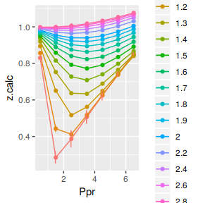

```
# A tibble: 112 x 5
   Tpr     Ppr z.chart z.calc       dif
   <chr> <dbl>   <dbl>  <dbl>     <dbl>
 1 1.05    0.5   0.829  0.830 -0.000976
 2 1.1     0.5   0.854  0.857 -0.00264
 3 1.2     0.5   0.893  0.894 -0.00146
 4 1.3     0.5   0.916  0.920 -0.00372
 5 1.4     0.5   0.936  0.937 -0.00149
 6 1.5     0.5   0.948  0.950 -0.00248
 7 1.6     0.5   0.959  0.960 -0.00126
 8 1.7     0.5   0.968  0.968  0.000216
 9 1.8     0.5   0.974  0.974  0.000310
10 1.9     0.5   0.978  0.978 -0.000398
# … with 102 more rows
```

```r
library(ggplot2)
library(tibble)

# get all `lp` Tpr curves
tpr_all <- getStandingKatzTpr(pprRange = "lp")
ppr <- c(0.5, 1.5, 2.5, 3.5, 4.5, 5.5, 6.5)

sk_corr_all <- createTidyFromMatrix(ppr, tpr_all, correlation = "DPR")
as.tibble(sk_corr_all)

p <- ggplot(sk_corr_all, aes(x=Ppr, y=z.calc, group=Tpr, color=Tpr)) +
    geom_line() +
    geom_point() +
    geom_errorbar(aes(ymin=z.calc-dif, ymax=z.calc+dif), width=.4,
                  position=position_dodge(0.05))
print(p)
```

> The greatest errors are localized in two of the Tpr curves: at 1.05 and 1.1.

## Range of applicability of the correlation

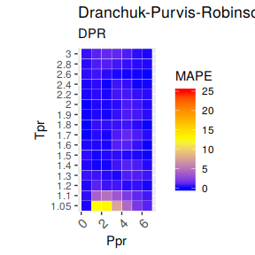

```r
# MSE: Mean Squared Error
# RMSE: Root Mean Squared Error
# RSS: residual sum of square
# ARE:  Average Relative Error, %
# AARE: Average Absolute Relative Error, %
library(dplyr)
grouped <- group_by(sk_corr_all, Tpr, Ppr)

smry_tpr_ppr <- summarise(grouped,
          RMSE= sqrt(mean((z.chart-z.calc)^2)),
          MPE = sum((z.calc - z.chart) / z.chart) * 100 / n(),
          MAPE = sum(abs((z.calc - z.chart) / z.chart)) * 100 / n(),
          MSE = sum((z.calc - z.chart)^2) / n(),
          RSS = sum((z.calc - z.chart)^2),
          MAE = sum(abs(z.calc - z.chart)) / n(),
          RMLSE = sqrt(1/n()*sum((log(z.calc +1)-log(z.chart +1))^2))
          )

ggplot(smry_tpr_ppr, aes(Ppr, Tpr)) +
    geom_tile(data=smry_tpr_ppr, aes(fill=MAPE), color="white") +
    scale_fill_gradient2(low="blue", high="red", mid="yellow", na.value = "pink",
                         midpoint=12.5, limit=c(0, 25), name="MAPE") +
    theme(axis.text.x = element_text(angle=45, vjust=1, size=11, hjust=1)) +
    coord_equal() +
    ggtitle("Dranchuk-Purvis-Robinson", subtitle = "DPR")
```

> The greatest errors are localized in two of the Tpr curves: 1.05 and barely at 1.1

## Plotting the `Tpr` and `Ppr` values that show more error

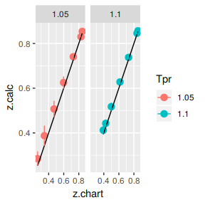

```r
library(dplyr)

sk_corr_all %>%
    filter(Tpr %in% c("1.05", "1.1")) %>%
    ggplot(aes(x = z.chart, y=z.calc, group = Tpr, color = Tpr)) +
    geom_point(size = 3) +
    geom_line(aes(x = z.chart, y = z.chart), color = "black") +
    facet_grid(. ~ Tpr) +
    geom_errorbar(aes(ymin=z.calc-abs(dif), ymax=z.calc+abs(dif)),
                  position=position_dodge(0.5))
```

## Looking numerically at the errors

Finally, the dataframe with the calculated errors between the `z` from the correlation and the `z` read from the chart:

```r
as_tibble(smry_tpr_ppr)
```

```
# A tibble: 112 x 9
   Tpr     Ppr     RMSE    MPE   MAPE        MSE        RSS     MAE   RMLSE
   <chr> <dbl>    <dbl>  <dbl>  <dbl>      <dbl>      <dbl>   <dbl>   <dbl>
 1 1.05    0.5 0.000976  0.118  0.118    9.52e-7    9.52e-7 9.76e-4 5.33e-4
 2 1.05    1.5 0.0320   12.6   12.6      1.02e-3    1.02e-3 3.20e-2 2.52e-2
 3 1.05    2.5 0.0445   13.0   13.0      1.98e-3    1.98e-3 4.45e-2 3.26e-2
 4 1.05    3.5 0.0361    7.67   7.67     1.31e-3    1.31e-3 3.61e-2 2.43e-2
 5 1.05    4.5 0.0271    4.54   4.54     7.36e-4    7.36e-4 2.71e-2 1.68e-2
 6 1.05    5.5 0.0137    1.89   1.89     1.88e-4    1.88e-4 1.37e-2 7.92e-3
 7 1.05    6.5 0.00809   0.957  0.957    6.55e-5    6.55e-5 8.09e-3 4.38e-3
 8 1.1     0.5 0.00264   0.309  0.309    6.95e-6    6.95e-6 2.64e-3 1.42e-3
 9 1.1     1.5 0.0169    3.98   3.98     2.87e-4    2.87e-4 1.69e-2 1.18e-2
10 1.1     2.5 0.0191    4.85   4.85     3.63e-4    3.63e-4 1.91e-2 1.36e-2
# … with 102 more rows
```

## References

Dranchuk, Peter M, RA Purvis, DB Robinson, and others. 1973. “Computer Calculation of Natural Gas Compressibility Factors Using the Standing and Katz Correlation.” In *Annual Technical Meeting*, edited by unknown. Petroleum Society of Canada. https://doi.org/10.2118/73-112.